# Predicting Pattern of Exercise based on Machine Learning Techniques

### Author: Veer Abhimanyu Singh

#### Date: 28th March, 2018

## Background

Using devices such as Jawbone Up, Nike FuelBand, and Fitbit it is now possible to collect a large amount of data about personal activity relatively inexpensively. These type of devices are part of the quantified self movement - a group of enthusiasts who take measurements about themselves regularly to improve their health, to find patterns in their behavior, or because they are tech geeks. One thing that people regularly do is quantify how much of a particular activity they do, but they rarely quantify how well they do it.

## Problem Statement/Goal

In this project, we will use data collected from accelerometers on the belt, forearm, arm, and dumbell of 6 participants. They were asked to perform barbell lifts correctly and incorrectly in 5 different ways. More information is available from the website here: http://groupware.les.inf.puc-rio.br/har (see the section on the Weight Lifting Exercise Dataset).

This project aims to predict in which manner participants completed a single exercise, based on recordings provided by accelerometers attached to 4 measurement points on the body. Six male participants aged 20-28 were asked to perform one set of 10 repetitions of the Unilateral Dumbbell Biceps Curl in one correct, and 4 incorrect fashions. Specifically, the exercises were performed: * Exactly according to the specification (Class A); * Throwing elbows to the front (Class B); * Lifting the dumbbell only halfway (Class C); * Lowering the dumbbell only halfway (Class D); and * Throwing the hips to the front (Class E).

## Data Preparation and Exploratory Data Analysis

### Data Overview

The training data for this project are available here:

https://d396qusza40orc.cloudfront.net/predmachlearn/pml-training.csv

The test data are available here:

https://d396qusza40orc.cloudfront.net/predmachlearn/pml-testing.csv

The data for this project come from this source: http://groupware.les.inf.puc-rio.br/har. If you use the document you create for this class for any purpose please cite them as they have been very generous in allowing their data to be used for this kind of assignment.

### Download and Clean Data

```r
# Load Libraries
library(knitr)
library(caret)
```

```r
library(rpart)
library(rpart.plot)
library(rattle)
library(randomForest)
library(corrplot)
library(gbm)
library(DMwR)
# set the URL for the download
UrlTrain <- "http://d396qusza40orc.cloudfront.net/predmachlearn/pml-training.csv"
UrlTest  <- "http://d396qusza40orc.cloudfront.net/predmachlearn/pml-testing.csv"

# download the datasets
training <- read.csv(url(UrlTrain))
testing  <- read.csv(url(UrlTest))

# create a partition with the training dataset into training and validation datasets
# set seed
set.seed(101)
inTrain  <- createDataPartition(training$classe, p=0.7, list=FALSE)
TrainSet <- training[inTrain, ]
ValSet  <- training[-inTrain, ]

# remove variables with Nearly Zero Variance
NZV <- nearZeroVar(TrainSet)
TrainSet <- TrainSet[, -NZV]
ValSet  <- ValSet[, -NZV]

# remove identification only variables (columns 1 to 5)
TrainSet <- TrainSet[, -(1:5)]
ValSet  <- ValSet[, -(1:5)]

# remove variables that are mostly NA
AllNA    <- sapply(TrainSet, function(x) mean(is.na(x))) > 0.95
TrainSet <- TrainSet[, AllNA==FALSE]
ValSet  <- ValSet[, AllNA==FALSE]

# Missing value imputation using k-nearset neighbour method
TrainSet <- knnImputation(TrainSet, k = 10, scale = T, meth = "weighAvg", distData = NULL)
ValSet <- knnImputation(ValSet, k = 10, scale = T, meth = "weighAvg", distData = NULL)
```

### Correlation Analysis

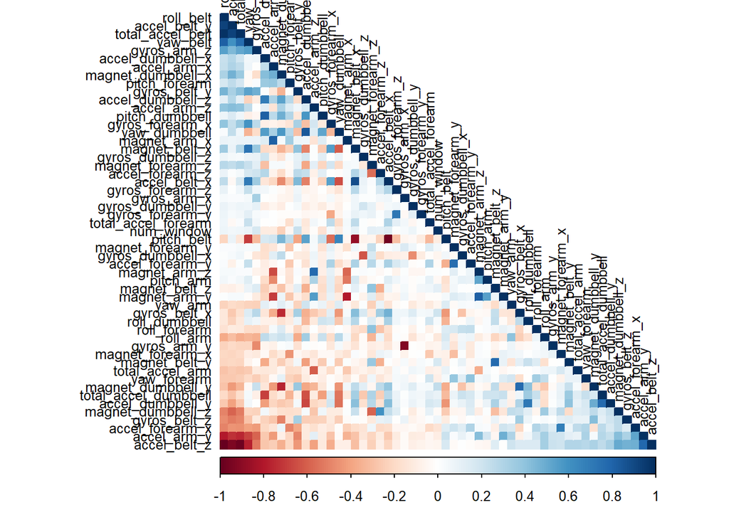

```r
# correlation matrix
corMatrix <- cor(TrainSet[, -54])
corrplot(corMatrix, order = "FPC", method = "color", type = "lower",
         tl.cex = 0.8, tl.col = rgb(0, 0, 0))
```

There are only a few correlated variables, therefore not dropping any variable for now.

## Predictive Model Building

### Method 01: Decision Trees

Building a decision tree model based on the training dataset

```r
set.seed(101)
modFitDecTree <- rpart(classe ~ ., data=TrainSet, method="class")
```

Confusion Matrix and Statistics

```r
# prediction on Validation dataset
predictDecTree <- predict(modFitDecTree, newdata=ValSet, type="class",na.action = na.pass)
confMatDecTree <- confusionMatrix(predictDecTree, ValSet$classe)
confMatDecTree
```

```
## Confusion Matrix and Statistics
##
##           Reference
## Prediction    A    B    C    D    E
##          A 1415  206   15   68   54
##          B   40  588   37   26   16
##          C   10   60  828  137   61
##          D  186  220   71  622  121
##          E   23   65   75  111  830
##
## Overall Statistics
##
##                Accuracy : 0.7278
##                  95% CI : (0.7162, 0.7391)
##     No Information Rate : 0.2845
##     P-Value [Acc > NIR] : < 2.2e-16
##
##                   Kappa : 0.6558
##  Mcnemar's Test P-Value : < 2.2e-16
##
## Statistics by Class:
##
##                      Class: A Class: B Class: C Class: D Class: E
## Sensitivity            0.8453  0.51624   0.8070   0.6452   0.7671
## Specificity            0.9185  0.97493   0.9448   0.8785   0.9430
## Pos Pred Value         0.8049  0.83168   0.7555   0.5098   0.7518
## Neg Pred Value         0.9372  0.89359   0.9587   0.9267   0.9473
## Prevalence             0.2845  0.19354   0.1743   0.1638   0.1839
## Detection Rate         0.2404  0.09992   0.1407   0.1057   0.1410
## Detection Prevalence   0.2987  0.12014   0.1862   0.2073   0.1876
## Balanced Accuracy      0.8819  0.74558   0.8759   0.7619   0.8550
```

### Method 02: Generalized Boosted Model

Building a Generalized Boosted model based on the training dataset

```r
# model fit
set.seed(101)
controlGBM <- trainControl(method = "repeatedcv", number = 5, repeats = 1)
modFitGBM  <- train(classe ~ ., data=TrainSet, method = "gbm",
                    trControl = controlGBM, verbose = FALSE)
modFitGBM$finalModel
```

```
## A gradient boosted model with multinomial loss function.
## 150 iterations were performed.
## There were 53 predictors of which 41 had non-zero influence.
```

Confusion Matrix and Statistics

```r
# prediction on Validation dataset
predictGBM <- predict(modFitGBM, newdata=ValSet)
confMatGBM <- confusionMatrix(predictGBM, ValSet$classe)
confMatGBM
```

```
## Confusion Matrix and Statistics
##
##           Reference
## Prediction    A    B    C    D    E
##          A 1671   14    0    0    0
##          B    3 1112   14    4    4
##          C    0   13 1010    7    0
##          D    0    0    2  952   10
##          E    0    0    0    1 1068
##
## Overall Statistics
##
##                Accuracy : 0.9878
##                  95% CI : (0.9846, 0.9904)
##     No Information Rate : 0.2845
##     P-Value [Acc > NIR] : < 2.2e-16
##
##                   Kappa : 0.9845
##  Mcnemar's Test P-Value : NA
##
## Statistics by Class:
##
##                      Class: A Class: B Class: C Class: D Class: E
## Sensitivity            0.9982   0.9763   0.9844   0.9876   0.9871
## Specificity            0.9967   0.9947   0.9959   0.9976   0.9998
## Pos Pred Value         0.9917   0.9780   0.9806   0.9876   0.9991
## Neg Pred Value         0.9993   0.9943   0.9967   0.9976   0.9971
## Prevalence             0.2845   0.1935   0.1743   0.1638   0.1839
## Detection Rate         0.2839   0.1890   0.1716   0.1618   0.1815
## Detection Prevalence   0.2863   0.1932   0.1750   0.1638   0.1816
## Balanced Accuracy      0.9974   0.9855   0.9901   0.9926   0.9934
```

### Method 03: Random Forest Model

Building a Random Forest model based on the training dataset

```r
# model fit
set.seed(101)
controlRF <- trainControl(method="cv", number=3, verboseIter=FALSE)
modFitRandForest <- train(classe ~ ., data=TrainSet, method="rf",
                          trControl=controlRF)
modFitRandForest$finalModel
```

```
##
## Call:
##  randomForest(x = x, y = y, mtry = param$mtry)
##                Type of random forest: classification
##                      Number of trees: 500
## No. of variables tried at each split: 27
##
##         OOB estimate of  error rate: 0.21%
## Confusion matrix:
##      A    B    C    D    E class.error
## A 3906    0    0    0    0 0.000000000
## B    4 2650    4    0    0 0.003009782
## C    0    5 2390    1    0 0.002504174
## D    0    0   11 2241    0 0.004884547
## E    0    1    0    3 2521 0.001584158
```

Confusion Matrix and Statistics

```r
# prediction on Validation dataset
predictRandForest <- predict(modFitRandForest, newdata=ValSet)
confMatRandForest <- confusionMatrix(predictRandForest, ValSet$classe)
confMatRandForest
```

```
## Confusion Matrix and Statistics
##
##           Reference
## Prediction    A    B    C    D    E
##          A 1672    2    0    0    0
##          B    1 1136    1    0    0
##          C    0    1 1025    2    0
##          D    0    0    0  961    4
##          E    1    0    0    1 1078
##
## Overall Statistics
##
##                Accuracy : 0.9978
##                  95% CI : (0.9962, 0.9988)
##     No Information Rate : 0.2845
##     P-Value [Acc > NIR] : < 2.2e-16
##
##                   Kappa : 0.9972
##  Mcnemar's Test P-Value : NA
##
## Statistics by Class:
##
##                      Class: A Class: B Class: C Class: D Class: E
## Sensitivity            0.9988   0.9974   0.9990   0.9969   0.9963
## Specificity            0.9995   0.9996   0.9994   0.9992   0.9996
## Pos Pred Value         0.9988   0.9982   0.9971   0.9959   0.9981
## Neg Pred Value         0.9995   0.9994   0.9998   0.9994   0.9992
## Prevalence             0.2845   0.1935   0.1743   0.1638   0.1839
## Detection Rate         0.2841   0.1930   0.1742   0.1633   0.1832
## Detection Prevalence   0.2845   0.1934   0.1747   0.1640   0.1835
## Balanced Accuracy      0.9992   0.9985   0.9992   0.9980   0.9979
```

## Predicting the outcome on the test dataset using the best model

Therefore, applying the best model (Random Forest Model) to predict the 20 cases in testing dataset:

```r
# Make prediction on test dataset
predictTEST <- predict(modFitRandForest, newdata=testing)
predictTEST
```

```
##  [1] B A B A A E D B A A B C B A E E A B B B
## Levels: A B C D E
```